# Assignment 4

Data Science for Biomedical Informatics (BMIN503/EPID600)

#### Visualization, Machine Learning and Model Evaluation

2. There is a simulated dataset [here](https://raw.githubusercontent.com/HimesGroup/BMIN503/master/DataFiles/assignment4_data.txt) of 100 measures taken for 1000 subjects. Read in the data file, and using some of the R functions discussed in class, answer the following questions by inserting code below each bullet to provide the answer directly. *(9 points)*:
   - How many cases/controls are in the dataset?

   ```r
   a4.data <- read.table(url("https://raw.githubusercontent.com/HimesGroup/BMIN503/master/DataFiles/assignment4_data.txt"), header=TRUE, sep="\t")
   table(a4.data$status)
   ```

   ```
   ##
   ##    Case Control
   ##     498     502
   ```

   - Use bivariate statistical tests to find out which variables are individually associated with *status* at a significance level <0.05. Name and list the variables with p<0.05, along with their p-values. The variable names can correspond to their order in the data (e.g., the first variable can be called “v1”). Among the signficant ones, which would you prioritize for further study? Hint: use a *for loop* so that you can get the 100 p-values efficiently.

   ```r
   n.var <- 100
   pvals <- as.list(rep(NA, n.var))
   names(pvals) <- sapply(c(1:n.var), function(i) {paste0("v", toString(i))})
   for (i in 1:n.var){
       glm.out <- glm(a4.data$status ~ a4.data[[i+1]], family=binomial("logit"))
       curr.p <- coef(summary(glm.out))[,4][2]
       pvals[i] <- curr.p
   }
   pvals[pvals<0.05]
   ```

   ```
   ## $v1
   ## [1] 1.549797e-41
   ##
   ## $v22
   ## [1] 0.03178584
   ##
   ## $v23
   ## [1] 5.579414e-32
   ##
   ## $v44
   ## [1] 0.01438925
   ##
   ## $v50
   ## [1] 9.536784e-15
   ##
   ## $v62
   ## [1] 0.03094128
   ##
   ## $v65
   ## [1] 0.00442541
   ##
   ## $v67
   ## [1] 0.004601439
   ##
   ## $v79
   ## [1] 0.04857065
   ##
   ## $v80
   ## [1] 0.03414728
   ##
   ## $v100
   ## [1] 2.328185e-33
   ```

   Four variables have very low p-values compared to all others: v1, v23, v50, v100
   - Create a plot to visualize how the values of the individual variable with lowest p-value differ between cases and controls.

   ```r
   library(ggplot2)
   pvals[pvals==min(unlist(pvals))]
   ```

   ```
   ## $v1
   ## [1] 1.549797e-41
   ```

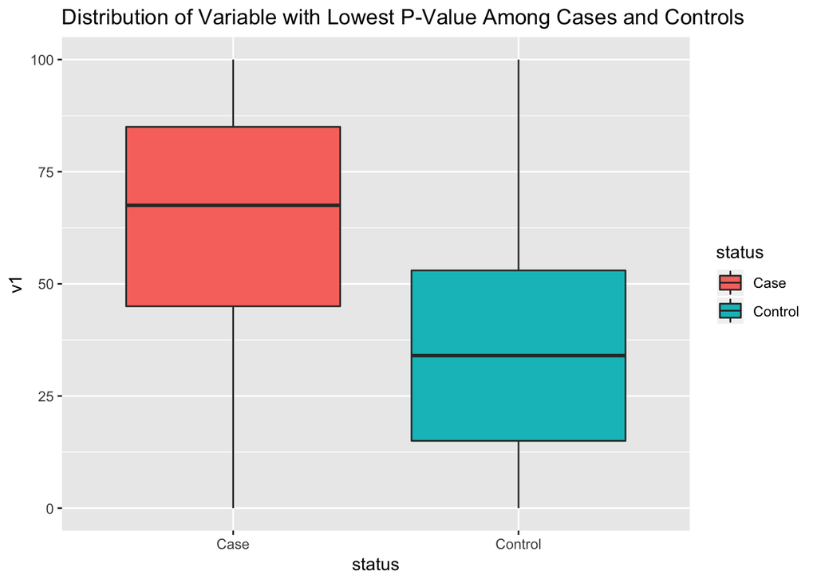

   ```r
   ggplot(a4.data, aes(status, v1)) +
       geom_boxplot(aes(fill=status)) +
       labs(title="Distribution of Variable with Lowest P-Value Among Cases and Controls")
   ```

3. We will use hierarchical clustering with the independent variables (i.e. exclude the *status* variable) to find out whether we can arrive at the *status* label from the independent variables. Since we know there should be 2 categories, use this information in your analysis. Insert code below each bullet to provide answers. *(9 points)*
   - Create a dendrogram using `hclust` and use the original *status* variable to color the leaves.

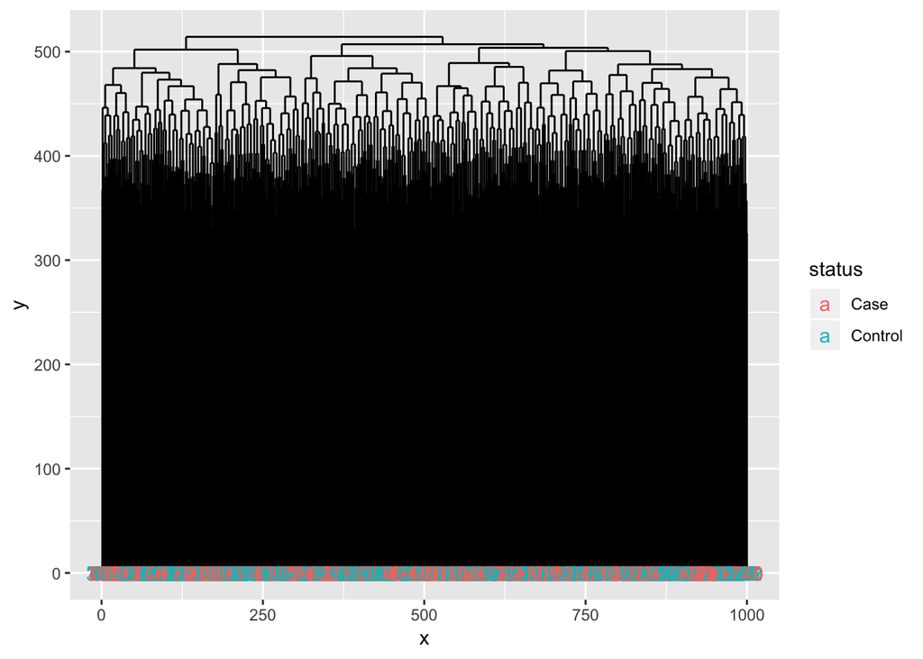

   ```r
   library(ggdendro)
   hclust <- hclust(dist(a4.data[, 2:101]), method="complete")
   dend <- dendro_data(as.dendrogram(hclust))
   dend.labels <- label(dend)
   dend.labels$status <- a4.data$status
   ggplot(segment(dend)) +
       geom_segment(aes(x=x, y=y, xend=xend, yend=yend)) +
       geom_text(data=dend.labels, aes(label=label, x=x, y=0, color=status))
   ```

   - Use a table to show how many cases/controls are properly classified.

   ```r
   hclust.pred <- cutree(hclust, 2)
   table(a4.data$status, hclust.pred)
   ```

   ```
   ##          hclust.pred
   ##             1   2
   ##   Case    154 344
   ##   Control 155 347
   ```

   - In 1-2 sentences describe the relationship between the independent variables and *status* based on your results.

Most variables are not related to *status* so hierarchical clustering is unable to group based on case/control status with the data given. Although a few individual variables were associated with *status*, the noise of the other variables is overwhelming the signal used for classification.

4. Compare the predictive accuracy of 1) Logistic regression and 2) Random forest multivariate models of *status* as outcome and using all independent variables simultaneously. Hint: you can modify the random forest and cross validation code from the practicum files used in class. Insert code below each bullet to provide answers. *(12 points)*
- Create a logistic regression model. How many variables are significant at p<0.05? Store the predicted values of the training data into a variable called glm.pred.

  ```r
  #Logistic regression
  a4.glm <- glm(status ~ ., data=a4.data, family=binomial(logit))
  summary(a4.glm)
  ```

  ```
  ##
  ## Call:
  ## glm(formula = status ~ ., family = binomial(logit), data = a4.data)
  ##
  ## Deviance Residuals:
  ##        Min          1Q      Median          3Q         Max
  ## -2.254e-04  -2.100e-08   2.100e-08   2.100e-08   2.081e-04
  ##
  ## Coefficients:
  ##               Estimate Std. Error z value Pr(>|z|)
  ## (Intercept)  2.501e+03  2.072e+05   0.012    0.990
  ## v1          -1.429e+01  6.863e+02  -0.021    0.983
  ## v2           3.306e-01  2.393e+02   0.001    0.999
  ## v3           6.459e-01  2.598e+02   0.002    0.998
  ## v4          -1.082e-01  2.603e+02   0.000    1.000
  ## v5           2.128e-01  3.608e+02   0.001    1.000
  ## v6           4.667e-01  3.905e+02   0.001    0.999
  ## v7          -1.297e+00  2.346e+02  -0.006    0.996
  ## v8          -2.825e-01  2.746e+02  -0.001    0.999
  ## v9          -6.527e-01  2.881e+02  -0.002    0.998
  ## v10         -4.384e-01  3.198e+02  -0.001    0.999
  ## v11          4.979e-02  2.545e+02   0.000    1.000
  ## v12         -4.058e-01  4.027e+02  -0.001    0.999
  ## v13          5.169e-01  4.384e+02   0.001    0.999
  ## v14         -6.190e-01  3.535e+02  -0.002    0.999
  ## v15         -4.294e-01  4.731e+02  -0.001    0.999
  ## v16          4.953e-01  3.717e+02   0.001    0.999
  ## v17          6.813e-01  3.179e+02   0.002    0.998
  ## v18         -4.184e-01  3.345e+02  -0.001    0.999
  ## v19          2.113e-01  5.554e+02   0.000    1.000
  ## v20          2.023e-01  3.609e+02   0.001    1.000
  ## v21          2.218e-02  4.568e+02   0.000    1.000
  ## v22          2.455e-01  1.668e+02   0.001    0.999
  ## v23         -1.195e+01  5.524e+02  -0.022    0.983
  ## v24          8.017e-01  2.609e+02   0.003    0.998
  ## v25         -6.256e-01  3.055e+02  -0.002    0.998
  ## v26         -1.288e-01  1.787e+02  -0.001    0.999
  ## v27          1.712e-03  2.249e+02   0.000    1.000
  ## v28          4.734e-01  5.284e+02   0.001    0.999
  ## v29          2.587e-01  5.043e+02   0.001    1.000
  ```

  [output cut: 64 more lines]

  ```
  ## v94         -9.101e-02  2.136e+02   0.000    1.000
  ## v95          6.001e-01  5.264e+02   0.001    0.999
  ## v96         -2.237e-01  4.592e+02   0.000    1.000
  ## v97          8.283e-02  3.245e+02   0.000    1.000
  ## v98          1.400e+00  5.183e+02   0.003    0.998
  ## v99         -1.106e-01  2.830e+02   0.000    1.000
  ## v100        -1.291e+01  6.482e+02  -0.020    0.984
  ##
  ## (Dispersion parameter for binomial family taken to be 1)
  ##
  ##     Null deviance: 1.3863e+03  on 999  degrees of freedom
  ## Residual deviance: 1.5168e-06  on 899  degrees of freedom
  ## AIC: 202
  ##
  ## Number of Fisher Scoring iterations: 25
  ```

  ```r
  glm.pred <- predict(a4.glm, a4.data, type="response")
  ```

  No variables are significant in the glm.
  - Create a random forest model. What are the most important predictors according to gini importance scores (i.e. MeanDecreaseGini)? Store the predicted values of the training data into a variable called rf.pred.

  ```r
  library(randomForest)
  rf <- randomForest(status ~ ., data=a4.data, ntree=100, importance=TRUE)
  rf
  ```

  ```
  ##
  ## Call:
  ##  randomForest(formula = status ~ ., data = a4.data, ntree = 100,      importance = TRUE)
  ##                Type of random forest: classification
  ##                      Number of trees: 100
  ## No. of variables tried at each split: 10
  ##
  ##         OOB estimate of  error rate: 19.1%
  ## Confusion matrix:
  ##         Case Control class.error
  ## Case     403      95   0.1907631
  ## Control   96     406   0.1912351
  ```

  ```r
  imp <- rf$importance
  head(sort(imp[,4], decreasing=TRUE), n=20)
  ```

  ```
  ##        v1       v23      v100       v50       v67       v65       v47       v94       v86       v42       v41       v79       v44       v36       v39       v81       v82        v9       v46       v32
  ## 56.845126 42.734251 41.933517 18.516070  5.782712  4.635064  4.478100  4.469662  4.374876  4.357265  4.347229  4.334082  4.315522  4.222291  4.202813  4.155487  4.143101  4.140335  4.111684  4.094521
  ```

  ```r
  rf.pred <- predict(rf, a4.data, type="prob")
  ```

  According to gini scores, 4 variables stand out: v1, v100, v23, v50.
  - Obtain 10-fold cross validation classification vectors for each model. Obtain AUC values and make an ROC plot that shows ROC curves corresponding to predictive accuracy using the training data as well as the 10-fold cross-validations. Note that there will be four ROC curves in your plot. What model was better at predicting *status*?

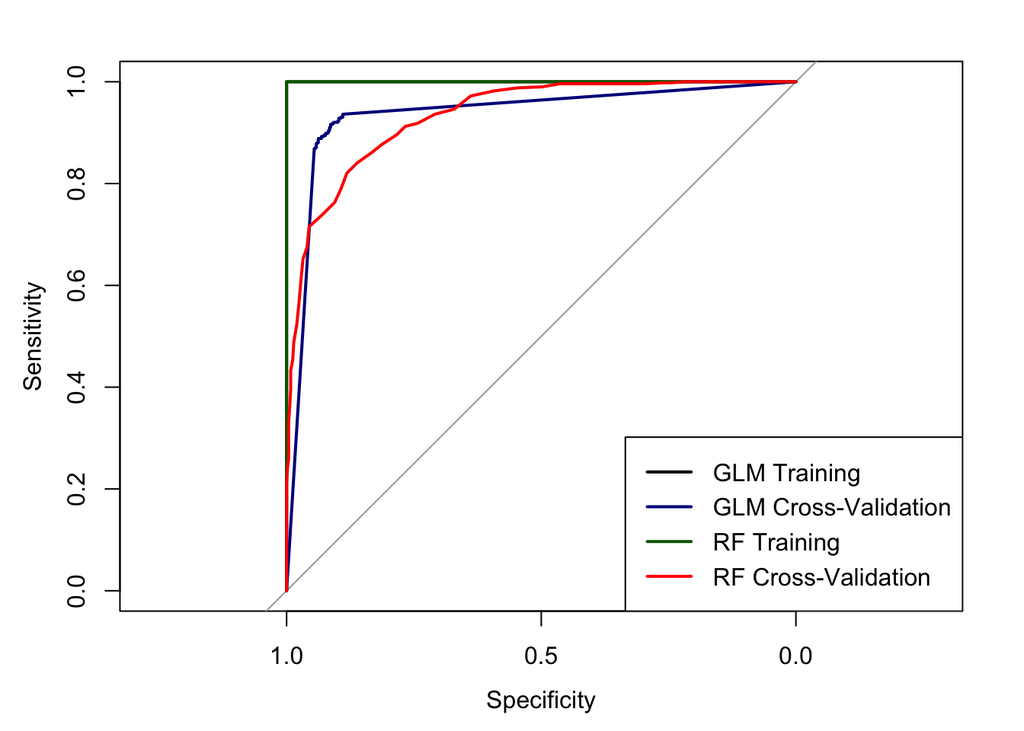

  ```r
  #10-fold cross-validation
  library(dplyr)
  N = nrow(a4.data)
  K = 10
  set.seed(1234)
  s = sample(1:K, size=N, replace=T)
  pred_outputs.glm <- vector(mode="numeric", length=N)
  pred_outputs.rf <- vector(mode="numeric", length=N)
  obs_outputs <- vector(mode="numeric", length=N)
  offset <- 0
  for(i in 1:K){
      train <- filter(a4.data, s != i)
      test <- filter(a4.data, s == i)
      obs_outputs[1:length(s[s==i]) + offset] <- test$status
      #GLM train/test
      glm <- glm(status~., data=train, family=binomial(logit))
      glm.pred.curr <- predict(glm, test, type="response")
      pred_outputs.glm[1:length(s[s==i]) + offset] <- glm.pred.curr

      #RF train/test
      rf <- randomForest(status~., data=train, ntree=100)
      rf.pred.curr <- predict(rf, newdata=test, type="prob")
      pred_outputs.rf[1:length(s[s==i]) + offset] <- rf.pred.curr[,2]

      offset <- offset + length(s[s==i])
  }

  #ROC curves - one plot of the four tests
  library(pROC)
  plot.roc(a4.data$status, glm.pred, ci=TRUE)
  plot.roc(obs_outputs, pred_outputs.glm, ci=TRUE, col="darkblue", add=TRUE)
  plot.roc(a4.data$status, rf.pred[, 2], ci=TRUE, col="darkgreen", add=TRUE)
  plot.roc(obs_outputs, pred_outputs.rf, ci=TRUE, col="red", add=TRUE)
  legend("bottomright", legend=c("GLM Training", "GLM Cross-Validation", "RF Training", "RF Cross-Validation"), col=c("black", "darkblue", "darkgreen", "red"), lwd=2)
  ```

  ```r
  auc(a4.data$status, glm.pred)
  ```

  ```
  ## Area under the curve: 1
  ```

  ```r
  auc(obs_outputs, pred_outputs.glm)
  ```

  ```
  ## Area under the curve: 0.9355
  ```

  ```r
  auc(a4.data$status, rf.pred[, 2])
  ```

  ```
  ## Area under the curve: 1
  ```

  ```r
  auc(obs_outputs, pred_outputs.rf)
  ```

  ```
  ## Area under the curve: 0.9344
  ```

-How do the AUCs for the random forest compare to the internal out-of-bag error rate estimate reported by the randomForest function? Explain how the two measures were obtained.

5. Rather than using all variables, create logistic regression and random forest predictive models using the “best” variables according to each method (i.e. the top-ranked variables according to standard metrics for each test). Insert code below each bullet to provide answers. *(9 points)*
   - Compare the top-ranked variables according to (1) p-values from logistic regression tests provided in question 2 and (2) by gini score for random forest from question 4. Are the top variables consistent?

   ```r
   names(pvals[pvals<1E-10])
   ```

   ```
   ## [1] "v1"   "v23"  "v50"  "v100"
   ```

   ```r
   names(imp[, 4][imp[, 4]>10])
   ```

   ```
   ## [1] "v1"   "v23"  "v50"  "v100"
   ```

   Yes, the top variables by each approach are the same.
   - Create logistic regression and random forest models using the top variables. For each model, check the predictive accuracy using the training data as well as via 10-fold cross-validation. Report the corresponding AUC and create ROC plots as you did in question 4. How does the predictive accuracy of the models compare to those using the entire dataset obtained in question 4? Explain any differences in a few sentences.

   ```r
   #Logistic regression
   a4.top.glm <- glm(status ~ v1+v23+v50+v100, data=a4.data, family=binomial(logit))
   summary(a4.top.glm)
   ```

   ```
   ##
   ## Call:
   ## glm(formula = status ~ v1 + v23 + v50 + v100, family = binomial(logit),
   ##     data = a4.data)
   ##
   ## Deviance Residuals:
   ##     Min       1Q   Median       3Q      Max
   ## -3.3853  -0.0875   0.0000   0.1027   2.8314
   ##
   ## Coefficients:
   ##              Estimate Std. Error z value Pr(>|z|)
   ## (Intercept) 27.588430   2.305218   11.97   <2e-16 ***
   ## v1          -0.161475   0.013885  -11.63   <2e-16 ***
   ## v23         -0.148840   0.013189  -11.29   <2e-16 ***
   ## v50         -0.080246   0.007977  -10.06   <2e-16 ***
   ## v100        -0.155154   0.013555  -11.45   <2e-16 ***
   ## ---
   ## Signif. codes:  0 '***' 0.001 '**' 0.01 '*' 0.05 '.' 0.1 ' ' 1
   ##
   ## (Dispersion parameter for binomial family taken to be 1)
   ##
   ##     Null deviance: 1386.28  on 999  degrees of freedom
   ## Residual deviance:  316.54  on 995  degrees of freedom
   ## AIC: 326.54
   ##
   ## Number of Fisher Scoring iterations: 8
   ```

   ```r
   glm.top.pred <- predict(a4.top.glm, a4.data, type="response")

   #Random Forest
   rf.top <- randomForest(status~v1+v23+v50+v100, data=a4.data, ntree=100, importance=TRUE)
   rf.top
   ```

   ```
   ##
   ## Call:
   ##  randomForest(formula = status ~ v1 + v23 + v50 + v100, data = a4.data,      ntree = 100, importance = TRUE)
   ##                Type of random forest: classification
   ##                      Number of trees: 100
   ## No. of variables tried at each split: 2
   ##
   ##         OOB estimate of  error rate: 9.4%
   ## Confusion matrix:
   ##         Case Control class.error
   ## Case     449      49  0.09839357
   ## Control   45     457  0.08964143
   ```

   ```r
   rf.top$importance
   ```

   ```
   ##            Case    Control MeanDecreaseAccuracy MeanDecreaseGini
   ## v1   0.15260521 0.15293829           0.15268184        156.14661
   ## v23  0.13102228 0.13471916           0.13275465        133.03800
   ## v50  0.04776413 0.04502749           0.04654754         73.11582
   ## v100 0.13138284 0.12718941           0.12934185        137.07286
   ```

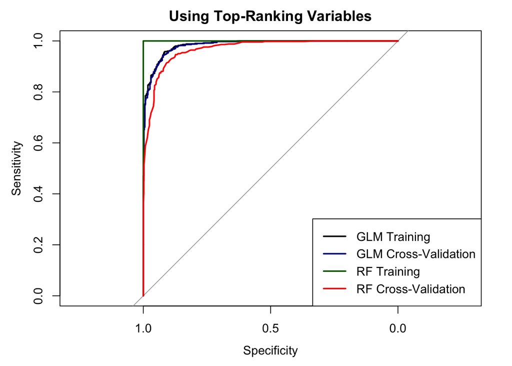

   ```r
   rf.top.pred <- predict(rf.top, a4.data, type="prob")

   #10-fold cross-validation
   N = nrow(a4.data)
   K = 10
   set.seed(1234)
   s = sample(1:K, size=N, replace=T)
   pred_outputs.glm <- vector(mode="numeric", length=N)
   pred_outputs.rf <- vector(mode="numeric", length=N)
   obs_outputs <- vector(mode="numeric", length=N)
   offset <- 0
   for(i in 1:K){
       train <- filter(a4.data, s != i)
       test <- filter(a4.data, s == i)
       obs_outputs[1:length(s[s==i]) + offset] <- test$status
       #GLM train/test
       glm <- glm(status~v1+v23+v50+v100, data=train, family=binomial(logit))
       glm.pred.curr <- predict(glm, test, type="response")
       pred_outputs.glm[1:length(s[s==i]) + offset] <- glm.pred.curr

       #RF train/test
       rf <- randomForest(status~v1+v23+v50+v100, data=train, ntree=100)
       rf.pred.curr <- predict(rf, newdata=test, type="prob")
       pred_outputs.rf[1:length(s[s==i]) + offset] <- rf.pred.curr[,2]

       offset <- offset + length(s[s==i])
   }

   #ROC Curves
   plot.roc(a4.data$status, glm.top.pred, ci=TRUE, main="Using Top-Ranking Variables")
   plot.roc(obs_outputs, pred_outputs.glm, ci=TRUE, col="darkblue", add=TRUE)
   plot.roc(a4.data$status, rf.top.pred[, 2], ci=TRUE, col="darkgreen", add=TRUE)
   plot.roc(obs_outputs, pred_outputs.rf, ci=TRUE, col="red", add=TRUE)
   legend("bottomright", legend=c("GLM Training", "GLM Cross-Validation", "RF Training", "RF Cross-Validation"), col=c("black", "darkblue", "darkgreen", "red"), lwd=2)
   ```

   ```r
   auc(a4.data$status, glm.pred)
   ```

   ```
   ## Area under the curve: 1
   ```

   ```r
   auc(obs_outputs, pred_outputs.glm)
   ```

   ```
   ## Area under the curve: 0.9835
   ```

   ```r
   auc(a4.data$status, rf.pred[, 2])
   ```

   ```
   ## Area under the curve: 1
   ```

   ```r
   auc(obs_outputs, pred_outputs.rf)
   ```

   ```
   ## Area under the curve: 0.9687
   ```

- What models would be preferable in most situations, those you created in question 4 or 5?

Those in question 5 since they are simpler, requiring 4 vs. 100 variables. In addition to adding cost to a test by virtue of requiring more measurements, the additional variables add noise to the model making prediction harder. That is, they obscure significant relationships between variables and outcome. For validation studies, it would also be preferable to move forward with 4 variables rather than 100.